# X_Lane_Detection

**STEP 1**

```python
# Step 1.1 — Mount Google Drive
from google.colab import drive
drive.mount('/content/drive')
```

```python
#Step 1.2 — Create a Project Folder in Google Drive
import os

# Create a folder in your Drive
project_path = "/content/drive/MyDrive/LaneDetection"
os.makedirs(project_path, exist_ok=True)

print(f"Project folder created at: {project_path}")
```

```
Project folder created at: /content/drive/MyDrive/LaneDetection
```

```python
#Step 1.3 — Change the Working Directory to the Project Folder
%cd /content/drive/MyDrive/LaneDetection
```

```
/content/drive/MyDrive/LaneDetection
```

```python
#Step 1.4 — Verify GPU Availability (Optional but Recommended)
!nvidia-smi
```

```
/bin/bash: line 1: nvidia-smi: command not found
```

**STEP 2**

**Step 2.1 — Create Dataset Folders We'll create separate folders to keep input images/videos and processed outputs organized.**

```python
import os

# Create dataset folders
os.makedirs("dataset/images", exist_ok=True)   # For road images or frames
os.makedirs("dataset/videos", exist_ok=True)   # If using videos
os.makedirs("output", exist_ok=True)           # For processed lane-detected results

print("Dataset folders created successfully!")
```

```
Dataset folders created successfully!
```

**Step 2.2 — Get Lane Detection Dataset**

**Option 1 — Use Your Own Images/Videos**

**Option 2 — Use a Public Dataset (Recommended for now)**

We’ll use the TuSimple Lane Detection Dataset or a small demo dataset for testing.

For a smaller sample dataset, let's download a few example road images from GitHub:

```python
!wget -P dataset/images https://raw.githubusercontent.com/udacity/CarND-LaneLines-P1/master/test_images/solidWhiteRight.jpg
!wget -P dataset/images https://raw.githubusercontent.com/udacity/CarND-LaneLines-P1/master/test_images/solidYellowCurve.jpg
!wget -P dataset/images https://raw.githubusercontent.com/udacity/CarND-LaneLines-P1/master/test_images/solidYellowLeft.jpg
!wget -P dataset/images https://raw.githubusercontent.com/udacity/CarND-LaneLines-P1/master/test_images/whiteCarLaneSwitch.jpg
```

[output not shown]

**Step 2.3 — Verify Dataset Download**

```python
import os

print("Available Images:")
for img in os.listdir("dataset/images"):
    print(img)
#This should list a few .jpg images of roads.
```

```
Available Images:
solidWhiteRight.jpg
solidYellowCurve.jpg
solidYellowLeft.jpg
whiteCarLaneSwitch.jpg
solidWhiteRight.jpg.1
solidYellowCurve.jpg.1
solidYellowLeft.jpg.1
whiteCarLaneSwitch.jpg.1
solidWhiteRight.jpg.2
solidYellowCurve.jpg.2
solidYellowLeft.jpg.2
whiteCarLaneSwitch.jpg.2
```

**Step 2.4 — Display One Sample **

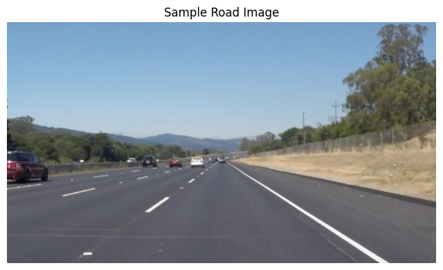

```python
#Let's make sure the dataset looks correct by visualizing one image.

import cv2
import matplotlib.pyplot as plt

# Pick one image to display
sample_image = "dataset/images/solidWhiteRight.jpg"

# Read and convert to RGB
image = cv2.imread(sample_image)
image = cv2.cvtColor(image, cv2.COLOR_BGR2RGB)

# Display image
plt.figure(figsize=(8, 6))
plt.imshow(image)
plt.axis("off")
plt.title("Sample Road Image")
plt.show()
```

**Step 3 — Preprocess Road Images**

**Before detecting lanes, we need to prepare the images so that lane markings stand out clearly.** **We'll perform four main steps:**

**Step 3.1 — Import Libraries**

```python
import cv2
import numpy as np
import matplotlib.pyplot as plt
import os
```

**Step 3.2 — Load a Sample Road**

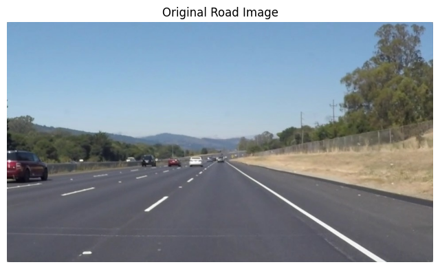

```python
# Load one road image
image_path = "dataset/images/solidWhiteRight.jpg"
image = cv2.imread(image_path)

# Convert BGR → RGB (for correct colors in matplotlib)
image = cv2.cvtColor(image, cv2.COLOR_BGR2RGB)

# Show the original image
plt.figure(figsize=(8, 6))
plt.imshow(image)
plt.title("Original Road Image")
plt.axis("off")
plt.show()
```

**Step 3.3 — Convert to Grayscale**

**Lane markings are white or yellow, so we don’t need full color information.**

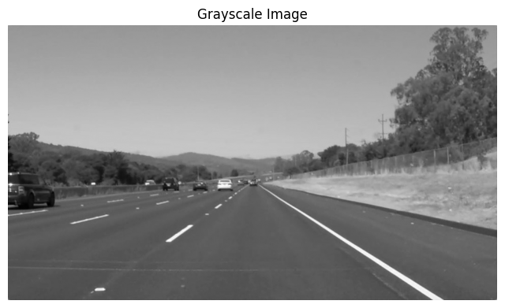

```python
gray = cv2.cvtColor(image, cv2.COLOR_RGB2GRAY)

plt.figure(figsize=(8, 6))
plt.imshow(gray, cmap="gray")
plt.title("Grayscale Image")
plt.axis("off")
plt.show()
```

**Step 3.4 — Apply Gaussian Blur**

**This removes noise and makes lane edges smoother.**

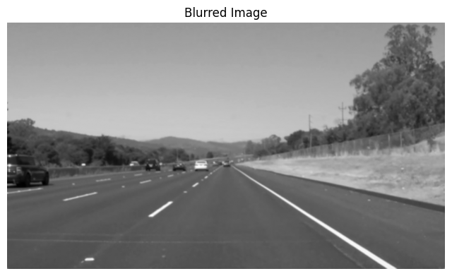

```python
blur = cv2.GaussianBlur(gray, (5, 5), 0)

plt.figure(figsize=(8, 6))
plt.imshow(blur, cmap="gray")
plt.title("Blurred Image")
plt.axis("off")
plt.show()
```

**Step 3.5 — Detect Edges Using Canny**

**Now we find edges, which highlight lane boundaries.**

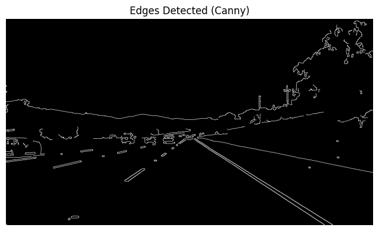

```python
edges = cv2.Canny(blur, 50, 150)

plt.figure(figsize=(8, 6))
plt.imshow(edges, cmap="gray")
plt.title("Edges Detected (Canny)")
plt.axis("off")
plt.show()
```

**Step 4 — Detect Lane Lines Using Hough Transform**

**After edge detection, we have an image where lane markings are highlighted.** **Now, we’ll use the Hough Line Transform to detect straight lines representing lanes.**

**Step 4.1 — Define a Region of Interest (ROI)**

**We don’t need the entire image, only the road area where lanes are visible.**

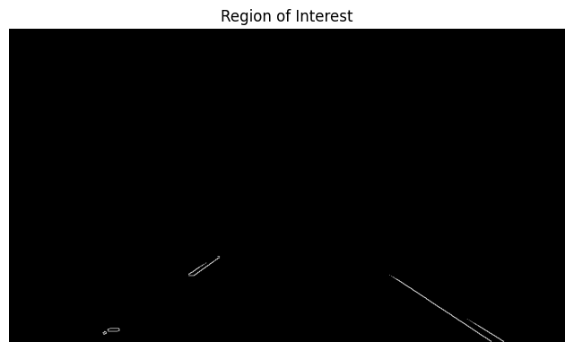

```python
def region_of_interest(image):
    height = image.shape[0]
    polygons = np.array([
        [(100, height), (image.shape[1]-100, height), (image.shape[1]//2, int(height*0.6))]
    ])
    mask = np.zeros_like(image)
    cv2.fillPoly(mask, polygons, 255)
    cropped = cv2.bitwise_and(image, mask)
    return cropped

roi = region_of_interest(edges)

plt.figure(figsize=(8, 6))
plt.imshow(roi, cmap="gray")
plt.title("Region of Interest")
plt.axis("off")
plt.show()
```

**Step 4.2 — Detect Lines with Hough Transform**

```python
# Histories for smoothing
_left_mb_hist = []
_right_mb_hist = []
_smooth_window = 10   # number of frames to average over


def _fit_lane_sides(lines, width):
    """
    Fit left and right lane lines from raw Hough line segments.
    Returns slope & intercept for both lanes.
    """
    left, right = [], []
    if lines is None:
        return None, None

    for x1, y1, x2, y2 in lines[:, 0]:
        slope = (y2 - y1) / (x2 - x1 + 1e-6)
        intercept = y1 - slope * x1
        if slope < 0 and x1 < width/2 and x2 < width/2:
            left.append((slope, intercept))
        elif slope > 0 and x1 > width/2 and x2 > width/2:
            right.append((slope, intercept))

    left_mb  = np.mean(left, axis=0) if len(left) > 0 else None
    right_mb = np.mean(right, axis=0) if len(right) > 0 else None
    return left_mb, right_mb


def _smooth_update(current, history):
    """
    Smooth lane line params using moving average.
    """
    if current is not None:
        history.append(current)
    if len(history) > _smooth_window:
        history.pop(0)
    return np.mean(history, axis=0) if len(history) > 0 else None


def _extrapolate_points(mb, height):
    """
    Convert slope & intercept to actual line segment points.
    """
    if mb is None:
        return None
    slope, intercept = mb
    y1 = height
    y2 = int(height * 0.6)  # draw line only partway up
    x1 = int((y1 - intercept) / slope)
    x2 = int((y2 - intercept) / slope)
    return (x1, y1, x2, y2)

# STEP 4.2 — Define the process_frame() function

import cv2
import numpy as np

def process_frame(frame):
    try:
        # Convert frame to grayscale
        gray = cv2.cvtColor(frame, cv2.COLOR_RGB2GRAY)

        # Reduce noise using Gaussian Blur
        blur = cv2.GaussianBlur(gray, (5, 5), 0)

        # Detect edges using Canny
        edges = cv2.Canny(blur, 50, 150)

        # Define region of interest (ROI)
        height = frame.shape[0]
        polygons = np.array([
            [(200, height), (frame.shape[1] - 200, height), (frame.shape[1] // 2, int(height * 0.6))]
        ])
        mask = np.zeros_like(edges)
        cv2.fillPoly(mask, polygons, 255)
        masked_edges = cv2.bitwise_and(edges, mask)

        # Use Hough Transform to detect lane lines
        lines = cv2.HoughLinesP(masked_edges, 2, np.pi/180, 100,
                                np.array([]), minLineLength=40, maxLineGap=5)

        # Draw lines on a blank image
        line_img = np.zeros_like(frame)
        if lines is not None:
            for line in lines:
                x1, y1, x2, y2 = line[0]
                cv2.line(line_img, (x1, y1), (x2, y2), (255, 0, 0), 10)

        # Merge original frame with detected lines
        combined = cv2.addWeighted(frame, 0.8, line_img, 1, 1)
        return combined
    except Exception as e:
        print("❌ Error in process_frame:", e)
        return frame
```

**Step 4.3 — Draw the Detected Lines**

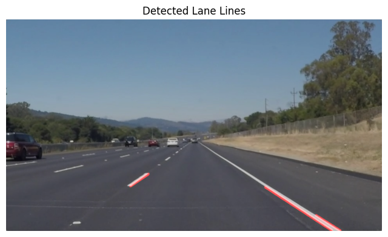

```python
# Convert to grayscale
gray = cv2.cvtColor(image, cv2.COLOR_RGB2GRAY)

# Blur
blur = cv2.GaussianBlur(gray, (5, 5), 0)

# Edge detection
edges = cv2.Canny(blur, 50, 150)

# ROI
masked_edges = region_of_interest(edges)

# Hough Transform -> this defines 'lines'
lines = cv2.HoughLinesP(masked_edges,
                        rho=2,
                        theta=np.pi/180,
                        threshold=50,
                        minLineLength=40,
                        maxLineGap=100)

# Now safe to draw lines
line_image = draw_lines(image, lines)

# Combine with original image
combo = cv2.addWeighted(image, 0.8, line_image, 1, 1)

def draw_lines(image, lines):
    line_image = np.zeros_like(image)
    if lines is not None:
        for line in lines:
            x1, y1, x2, y2 = line[0]
            cv2.line(line_image, (x1, y1), (x2, y2), (255, 0, 0), 5)
    return line_image

line_image = draw_lines(image,lines)

# Combine original image + lines
combo_image = cv2.addWeighted(image, 0.8, line_image, 1, 1)

plt.figure(figsize=(8, 6))
plt.imshow(combo_image)
plt.title("Detected Lane Lines")
plt.axis("off")
plt.show()
```

**STEP 5** **Step 5.1 — Download Sample Test Videos 🎥**

**In this step, we create folders to store videos and then download sample driving videos from Udacity’s dataset.**

```python
!mkdir -p dataset/videos dataset/videos_output
!wget -nc -P dataset/videos https://raw.githubusercontent.com/udacity/CarND-LaneLines-P1/master/test_videos/solidWhiteRight.mp4
```

```
File ‘dataset/videos/solidWhiteRight.mp4’ already there; not retrieving.
```

**5.2 — Process Each Frame: Lane Detection with Bright Red Lines & Green Highlight**

**This function processes each frame of the video, detects lane lines, draws bold bright red lane boundaries, and highlights the lane coverage area in green for better visibility.**

```python
def process_frame(frame_rgb):
    """
    Lane detection pipeline with:
    - Brighter, bold red lane boundary lines
    - Smooth green lane area highlight
    """
    h, w = frame_rgb.shape[:2]

    # 1) Convert to grayscale, blur, and detect edges
    gray = cv2.cvtColor(frame_rgb, cv2.COLOR_RGB2GRAY)
    blur = cv2.GaussianBlur(gray, (5, 5), 0)
    edges = cv2.Canny(blur, 50, 150)

    # 2) Region of Interest (ROI)
    edges_roi = region_of_interest(edges)

    # 3) Hough Transform to detect raw lane lines
    raw = cv2.HoughLinesP(edges_roi, rho=2, theta=np.pi/180, threshold=50,
                          minLineLength=40, maxLineGap=120)

    # 4) Fit left & right lane lines and smooth them
    left_mb, right_mb = _fit_lane_sides(raw, w)
    left_mb_s = _smooth_update(left_mb, _left_mb_hist)
    right_mb_s = _smooth_update(right_mb, _right_mb_hist)

    # 5) Create an overlay for drawing
    overlay = np.zeros_like(frame_rgb)

    left_pts = _extrapolate_points(left_mb_s, h)
    right_pts = _extrapolate_points(right_mb_s, h)

    # --- Draw THICK, BRIGHT RED lane lines ---
    bright_red = (255, 0, 0)  # Pure bright red in RGB
    if left_pts is not None:
        cv2.line(overlay, (left_pts[0], left_pts[1]), (left_pts[2], left_pts[3]), bright_red, 18)
    if right_pts is not None:
        cv2.line(overlay, (right_pts[0], right_pts[1]), (right_pts[2], right_pts[3]), bright_red, 18)

    # --- Fill the polygon between lanes with GREEN ---
    if left_pts is not None and right_pts is not None:
        poly = np.array([
            [left_pts[0],  left_pts[1]],
            [left_pts[2],  left_pts[3]],
            [right_pts[2], right_pts[3]],
            [right_pts[0], right_pts[1]],
        ], dtype=np.int32)
        cv2.fillPoly(overlay, [poly], (0, 255, 0))  # Green fill

    # --- Blend overlay on the original frame ---
    out = cv2.addWeighted(frame_rgb, 1.0, overlay, 0.45, 0)

    return out
```

**5.3 — Process the Input Video Frame by Frame and Save the Output** **In this step, we:**

**Open the input driving video using OpenCV.**

**Read each frame, process it using our lane detection pipeline (process_frame()), and draw bright red lane lines plus a green highlighted lane area.**

**Save the processed frames into a new output MP4 video.**

```python
import os

input_video  = "dataset/videos/solidWhiteRight.mp4"     # change if you want
out_mp4      = "dataset/videos_output/solidWhiteRight_smooth.mp4"
os.makedirs("dataset/videos_output", exist_ok=True)

cap = cv2.VideoCapture(input_video)
if not cap.isOpened():
    raise FileNotFoundError(f"Could not open: {input_video}")

fps = cap.get(cv2.CAP_PROP_FPS) or 20.0  # fallback if 0
w   = int(cap.get(cv2.CAP_PROP_FRAME_WIDTH))
h   = int(cap.get(cv2.CAP_PROP_FRAME_HEIGHT))

fourcc = cv2.VideoWriter_fourcc(*"mp4v")
writer = cv2.VideoWriter(out_mp4, fourcc, fps, (w, h))

frames = 0
while True:
    ret, bgr = cap.read()
    if not ret:
        break
    rgb = cv2.cvtColor(bgr, cv2.COLOR_BGR2RGB)
    processed_rgb = process_frame(rgb)
    processed_bgr = cv2.cvtColor(processed_rgb, cv2.COLOR_RGB2BGR)
    writer.write(processed_bgr)
    frames += 1

cap.release()
writer.release()
print(f"✅ Saved MP4 with smoothing + green fill: {out_mp4} (frames: {frames})")
```

```
✅ Saved MP4 with smoothing + green fill: dataset/videos_output/solidWhiteRight_smooth.mp4 (frames: 221)
```

**5.4 — Convert Processed Video to a Browser-Friendly Format for Colab Playback 🎥**

**In this step:**

**We convert the processed MP4 video into the WebM format using FFmpeg.**

**WebM is more browser-friendly and works seamlessly with Google Colab’s inline video player.**

**The final converted video can be easily displayed directly within the Colab notebook.**

```python
out_webm = "dataset/videos_output/solidWhiteRight_smooth.webm"
# Convert to a browser-friendly format for Colab inline player
!ffmpeg -y -i dataset/videos_output/solidWhiteRight_smooth.mp4 -c:v libvpx-vp9 -b:v 2M -c:a libopus {out_webm}
print("✅ Re-encoded for Colab:", out_webm)
```

[output not shown]

**5.5 — Display the Processed Video Inline in Colab 🎬** **In this step: **

**We embed the processed video directly into the Colab notebook.**

**The video is first read and base64 encoded.**

**Finally, we use HTML to create an inline video player where you can watch the lane detection output seamlessly inside the notebook.**

```python
from IPython.display import HTML
from base64 import b64encode

with open(out_webm, "rb") as f:
    data_url = "data:video/webm;base64," + b64encode(f.read()).decode()

HTML(f'<video width="720" controls><source src="{data_url}" type="video/webm"></video>')
```

[video not shown]